# Basic Vision Recognition Using FastAI

Basic example of training a model to recognize whether an image is of a cat or not. Based off of lesson 1 of FastAI's course.

Pre-reqs: -familiarity with python -jupyter notebook environment with GPU(Running this in Google Collab

# Part 1: Gathering Data

```python
!pip install -Uqq fastai
!pip install -Uqq duckduckgo_search
```

```python
from duckduckgo_search import ddg_images
from fastcore.all import *

def search_images(term, max_images=200):
    return L(ddg_images(term, max_results=max_images)).itemgot('image')
```

We'll create a function here to facilitate gathering images from DuckDuckGo. 'L' here is fastai's modified version of a list datastructure.

```python
urls = search_images('cat photo', max_images=1)
urls[0]
```

```
'https://static.pexels.com/photos/45201/kitty-cat-kitten-pet-45201.jpeg'
```

We can see that we're getting an image URL back, so it appears everything is working as expected thus far.

Okay let's now download that url and view the image to make sure that's working too.

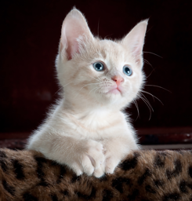

```python
from fastdownload import download_url
dest = 'cat.jpg'
download_url(urls[0], dest, show_progress=False)

from fastai.vision.all import *
im = Image.open(dest)
im.to_thumb(256,256)
```

Let's pick another, non-cat, category of data to gather. I'll pick trees.

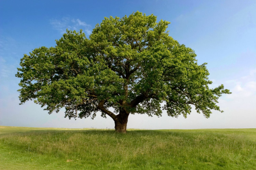

```python
download_url(search_images('tree photos', max_images=1)[0], 'tree.jpg', show_progress=False)
Image.open('tree.jpg').to_thumb(256,256)
```

Looks like that's also working thus far as we can see the tree here we've downloaded.

Okay, let's gather data to train on for both categories.

```python
searches = 'forest', 'cat'
path = Path('cat_or_not')

from time import sleep

for o in searches:
    dest = (path/o)
    dest.mkdir(exist_ok=True, parents=True)
    download_images(dest, urls=search_images(f'{o} photo'))
    sleep(10)
    download_images(dest, urls=search_images(f'{o} sun photo'))
    sleep(10)
    download_images(dest, urls=search_images(f'{o} shade photo'))
    sleep(10)
    resize_images(path/o, max_size=400, dest=path/o)
```

This for loop goes through each category, makes a directory for each category to store the images, searches for the term with different lighting, and resizes all the images to be 400.

Some of the images we tried to gather may have had errors, which could later cause problems. So next let's get rid of those.

```python
failed = verify_images(get_image_files(path))
failed.map(Path.unlink)
len(failed)
```

```
19
```

# Part 2: Training the Model

Now, let's organize the data.

[figure not shown]

```python
dls = DataBlock(
    blocks=(ImageBlock, CategoryBlock),
    get_items=get_image_files,
    splitter=RandomSplitter(valid_pct=0.2, seed=42),
    get_y=parent_label,
    item_tfms=[Resize(192, method='squish')]
).dataloaders(path)

dls.show_batch(max_n=6)
```

Here we make a dataloader object to seperate the training and validation data set.

Let's walk through line through line what's going on here.

"blocks=(ImageBlock, CategoryBlock)" ImageBlock identifies what type of data we're sending in while CategoryBlock tells us our output. We're feeding it images, and expecting it to be categorized.

"get_items=get_image_files"

This communicates how to find and access the data

"splitter=RandomSplitter(valid_pct=0.2, seed=42)"

Here we seperate 20% of the data to be used for verification purposes.

"get_y=parent_label"

Specifies that the parent folder of each file or piece of data should be used to label what category it's in.

"item_tfms=[Resize(192, method='squish')]"

Images have to be of the same size in order to be trained. This specifies that all images will be 192 by 192 and it will shrink the images by squishing them if need be.

```python
learn = vision_learner(dls, resnet18, metrics=error_rate)
learn.fine_tune(4)
```

| epoch | train_loss | valid_loss | error_rate | time |
| --- | --- | --- | --- | --- |
| 0 | 0.613148 | 0.299313 | 0.080000 | 00:01 |

| epoch | train_loss | valid_loss | error_rate | time |
| --- | --- | --- | --- | --- |
| 0 | 0.102046 | 0.112397 | 0.020000 | 00:01 |
| 1 | 0.059464 | 0.077351 | 0.010000 | 00:01 |
| 2 | 0.037714 | 0.055643 | 0.010000 | 00:01 |
| 3 | 0.026807 | 0.042051 | 0.010000 | 00:01 |

Here we train the model. dls is our organized data, resnet18 is a widely used vision model we'll build off of, and error_rate is how we'll measure the performance of the model.

We'll fine tune 4 times here. Meaning we'll take the pretained model, resnet18, and fit it to be trained off our specific dataset and task.

Now let's test our model by feeding it the cat.jpg we downloaded earlier.

```python
is_cat, _, probs = learn.predict(PILImage.create('cat.jpg'))
print(f"This is a picture of a {is_cat}.")
print(f"Probability it's a cat: {probs[0]:.4f}")
```

```
This is a picture of a cat.
Probability it's a cat: 1.0000
```

Great, it succesfully identified the image.